# yqol_factor_analysis

Drew Walker

12/17/2021

# Load data

```r
yqolsf_scores <- read_csv("yqolsf_factor_ready.csv")
yqolsf_scores <- yqolsf_scores %>%
  filter(yqolsf_complete == 2) %>%
  select(-yqolsf_complete,-record_id)
describe(yqolsf_scores)
```

```
##     vars  n mean   sd median trimmed  mad min max range  skew kurtosis   se
## r07    1 66 2.21 0.64      2    2.26 0.00   1   3     2 -0.22    -0.74 0.08
## r08    2 66 2.20 0.73      2    2.24 1.48   1   3     2 -0.31    -1.11 0.09
## r11    3 65 2.65 0.57      3    2.74 0.00   1   3     2 -1.32     0.72 0.07
## r13    4 66 2.61 0.52      3    2.65 0.00   1   3     2 -0.74    -0.79 0.06
## r16    5 64 2.81 0.50      3    2.94 0.00   1   3     2 -2.59     5.76 0.06
## r19    6 64 2.69 0.61      3    2.83 0.00   1   3     2 -1.74     1.75 0.08
## r20    7 64 2.75 0.53      3    2.87 0.00   1   3     2 -2.00     3.03 0.07
## r24    8 64 2.75 0.50      3    2.85 0.00   1   3     2 -1.83     2.51 0.06
## r26    9 64 2.19 0.79      2    2.23 1.48   1   3     2 -0.34    -1.37 0.10
## r27   10 65 2.49 0.62      3    2.57 0.00   1   3     2 -0.76    -0.46 0.08
## r32   11 65 2.74 0.51      3    2.83 0.00   1   3     2 -1.74     2.14 0.06
## r34   12 65 2.94 0.24      3    3.00 0.00   2   3     1 -3.57    10.88 0.03
## r35   13 63 2.63 0.58      3    2.73 0.00   1   3     2 -1.27     0.59 0.07
## r36   14 65 2.77 0.42      3    2.83 0.00   2   3     1 -1.25    -0.45 0.05
## r37   15 67 2.82 0.42      3    2.91 0.00   1   3     2 -2.21     4.22 0.05
## r38   16 60 2.57 0.62      3    2.67 0.00   1   3     2 -1.08     0.06 0.08
```

```r
yqolsf_descriptives <- describe(yqolsf_scores)
write_csv(yqolsf_descriptives, "yqolsf_descriptives.csv")
```

# EFA

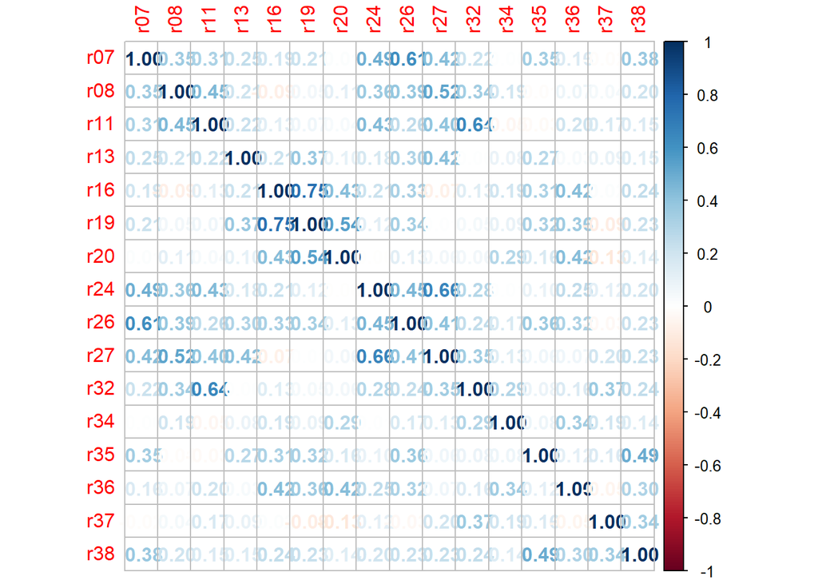

```r
datamatrix <- cor(yqolsf_scores, method = "pearson", use = "complete.obs")
corrplot(datamatrix, method="number")
```

```r
KMO(r=cor(yqolsf_scores,method = "pearson", use = "complete.obs"))
```

```
## Kaiser-Meyer-Olkin factor adequacy
## Call: KMO(r = cor(yqolsf_scores, method = "pearson", use = "complete.obs"))
## Overall MSA =  0.61
## MSA for each item =
##  r07  r08  r11  r13  r16  r19  r20  r24  r26  r27  r32  r34  r35  r36  r37  r38
## 0.81 0.68 0.52 0.43 0.66 0.63 0.61 0.65 0.77 0.62 0.54 0.37 0.65 0.61 0.59 0.61
```

```r
cortest.bartlett(yqolsf_scores)
```

```
## R was not square, finding R from data
```

```
## $chisq
## [1] 405.6968
##
## $p.value
## [1] 1.07946e-32
##
## $df
## [1] 120
```

```r
det(cor(yqolsf_scores,method = "pearson", use = "complete.obs"))
```

```
## [1] 0.0006441726
```

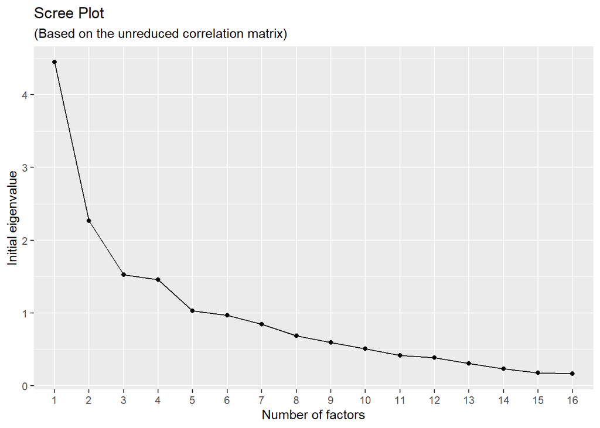

```r
fafitfree <- fa(yqolsf_scores,nfactors = ncol(yqolsf_scores), rotate = "none")
n_factors <- length(fafitfree$e.values)
scree     <- data.frame(
  Factor_n =  as.factor(1:n_factors),
  Eigenvalue = fafitfree$e.values)
ggplot(scree, aes(x = Factor_n, y = Eigenvalue, group = 1)) +
  geom_point() + geom_line() +
  xlab("Number of factors") +
  ylab("Initial eigenvalue") +
  labs( title = "Scree Plot",
        subtitle = "(Based on the unreduced correlation matrix)")
```

```r
psych::alpha(yqolsf_scores)
```

```
##
## Reliability analysis
## Call: psych::alpha(x = yqolsf_scores)
##
##   raw_alpha std.alpha G6(smc) average_r S/N   ase mean  sd median_r
##       0.82      0.81    0.88      0.21 4.3 0.031  2.6 0.3     0.19
##
##  lower alpha upper     95% confidence boundaries
## 0.76 0.82 0.88
##
##  Reliability if an item is dropped:
##     raw_alpha std.alpha G6(smc) average_r S/N alpha se var.r med.r
## r07      0.80      0.80    0.87      0.21 4.0    0.035 0.027  0.19
## r08      0.80      0.80    0.87      0.21 4.0    0.034 0.027  0.19
## r11      0.81      0.80    0.87      0.21 4.1    0.033 0.027  0.19
## r13      0.81      0.80    0.88      0.21 4.1    0.033 0.029  0.19
## r16      0.81      0.80    0.87      0.21 4.0    0.033 0.026  0.19
## r19      0.80      0.80    0.86      0.21 4.0    0.033 0.024  0.19
## r20      0.81      0.81    0.87      0.22 4.2    0.032 0.026  0.19
## r24      0.80      0.80    0.87      0.21 3.9    0.034 0.026  0.19
## r26      0.80      0.79    0.87      0.20 3.9    0.036 0.028  0.16
## r27      0.80      0.80    0.86      0.21 3.9    0.035 0.026  0.19
## r32      0.81      0.80    0.87      0.21 4.0    0.033 0.029  0.18
## r34      0.82      0.81    0.88      0.23 4.4    0.032 0.028  0.21
## r35      0.81      0.81    0.88      0.22 4.2    0.033 0.028  0.19
## r36      0.81      0.80    0.87      0.21 4.0    0.033 0.028  0.19
## r37      0.82      0.82    0.88      0.24 4.6    0.031 0.025  0.21
## r38      0.81      0.80    0.87      0.21 4.0    0.033 0.029  0.18
##
##  Item statistics
##      n raw.r std.r r.cor r.drop mean   sd
## r07 66  0.62  0.57  0.54  0.514  2.2 0.64
## r08 66  0.58  0.54  0.51  0.461  2.2 0.73
## r11 65  0.57  0.51  0.48  0.420  2.6 0.57
## r13 66  0.48  0.49  0.45  0.406  2.6 0.52
## r16 64  0.55  0.56  0.55  0.456  2.8 0.50
## r19 64  0.56  0.56  0.56  0.451  2.7 0.61
## r20 64  0.44  0.45  0.42  0.323  2.8 0.53
## r24 64  0.62  0.59  0.58  0.531  2.8 0.50
## r26 64  0.68  0.63  0.60  0.562  2.2 0.79
```

[output cut: 11 more lines]

```
## r08 0.18 0.44 0.38 0.03
## r11 0.05 0.26 0.69 0.04
## r13 0.02 0.36 0.62 0.03
## r16 0.05 0.09 0.86 0.06
## r19 0.08 0.16 0.77 0.06
## r20 0.05 0.16 0.80 0.06
## r24 0.03 0.19 0.78 0.06
## r26 0.23 0.34 0.42 0.06
## r27 0.06 0.38 0.55 0.04
## r32 0.03 0.20 0.77 0.04
## r34 0.00 0.06 0.94 0.04
## r35 0.05 0.27 0.68 0.07
## r36 0.00 0.23 0.77 0.04
## r37 0.01 0.15 0.84 0.01
## r38 0.07 0.30 0.63 0.12
```

```r
fa.none <- fa(r=yqolsf_scores,nfactors = 3, fm="mle", max.iter=100, rotate="oblimin")
print(fa.none)
```

```
## Factor Analysis using method =  ml
## Call: fa(r = yqolsf_scores, nfactors = 3, rotate = "oblimin", max.iter = 100,
##     fm = "mle")
## Standardized loadings (pattern matrix) based upon correlation matrix
##       ML3   ML2   ML1    h2    u2 com
## r07  0.68  0.06 -0.07 0.448 0.552 1.0
## r08  0.55 -0.06  0.16 0.378 0.622 1.2
## r11  0.26  0.00  0.54 0.464 0.536 1.4
## r13  0.32  0.38 -0.05 0.278 0.722 2.0
## r16  0.01  0.79  0.01 0.631 0.369 1.0
## r19 -0.03  0.94 -0.02 0.865 0.135 1.0
## r20 -0.02  0.61  0.05 0.381 0.619 1.0
## r24  0.73  0.04  0.02 0.551 0.449 1.0
## r26  0.56  0.23 -0.04 0.410 0.590 1.4
## r27  0.83 -0.11  0.03 0.676 0.324 1.0
## r32 -0.02  0.01  1.00 0.995 0.005 1.0
## r34 -0.04  0.11  0.24 0.073 0.927 1.5
## r35  0.20  0.28 -0.02 0.139 0.861 1.8
## r36  0.04  0.44  0.21 0.284 0.716 1.4
## r37  0.00 -0.14  0.30 0.097 0.903 1.4
## r38  0.24  0.15  0.13 0.147 0.853 2.3
##
##                        ML3  ML2  ML1
## SS loadings           2.68 2.50 1.63
## Proportion Var        0.17 0.16 0.10
## Cumulative Var        0.17 0.32 0.43
## Proportion Explained  0.39 0.37 0.24
## Cumulative Proportion 0.39 0.76 1.00
##
##  With factor correlations of
##      ML3  ML2  ML1
## ML3 1.00 0.22 0.39
## ML2 0.22 1.00 0.15
## ML1 0.39 0.15 1.00
##
## Mean item complexity =  1.3
## Test of the hypothesis that 3 factors are sufficient.
##
## The degrees of freedom for the null model are  120  and the objective function was  6.67 with Chi Square of  405.7
## The degrees of freedom for the model are 75  and the objective function was  1.97
##
## The root mean square of the residuals (RMSR) is  0.08
## The df corrected root mean square of the residuals is  0.1
##
## The harmonic number of observations is  63 with the empirical chi square  98.4  with prob <  0.036
## The total number of observations was  68  with Likelihood Chi Square =  115.78  with prob <  0.0018
##
## Tucker Lewis Index of factoring reliability =  0.76
## RMSEA index =  0.088  and the 90 % confidence intervals are  0.056 0.121
## BIC =  -200.68
## Fit based upon off diagonal values = 0.91
## Measures of factor score adequacy
##                                                    ML3  ML2  ML1
## Correlation of (regression) scores with factors   0.92 0.95 1.00
## Multiple R square of scores with factors          0.85 0.91 0.99
## Minimum correlation of possible factor scores     0.70 0.81 0.99
```

```r
loadings <- unclass(fa.none$loadings)
h2 <- fa.none$communalities
#There is also factors_data$communality which has same values
u2 <- fa.none$uniquenesses
com <- fa.none$complexity
yqsol_factor_loadings <- cbind(loadings, h2, u2, com)
yqsol_factor_loadings <- as.data.frame(yqsol_factor_loadings)
yqsol_factor_loadings <- tibble::rownames_to_column(yqsol_factor_loadings, "question")

write_csv(yqsol_factor_loadings, "yqsol_factor_loadings.csv")
```

# CFA based on [@hoang2021]

## Factor 1: Belief in self and family

- Q1 (r07): energy to do the things i want
- Q2: (r_missing) Feel good about self
- Q3: (r missing) I feel i am important to others
- Q4 (r08): pleased with how i look
- Q5 (r_missing) feel understood by family
- Q6 (r_missing) feel i am getting along with my family
- Q5 (r16): my family encourages me to do my best
- Q6 (r19): i feel i am getting along with my parents or guardians
- Q15 (r20): I feel my parents or guardians allow me to participate in important decisions which affect me

## Factor 2: Environment and relationships

- Q8 (r24): I’m happy with the friends I have
- Q9(r26): I feel i can take part in same activities as others my age
- Q10(r27): People my age treat me with respect

Q12 (r32) I look forward to the future * Q13 (r34): I feel safe when i am at home * Q14 (r35): Getting a good education

## NEW:

### Removed:

- Q2: (r_missing) Feel good about self
- Q3: (r missing) I feel i am important to others
- Q5 (r_missing) feel understood by family
- Q6 (r_missing) feel i am getting along with my family
- Q11 (r_missing) Not in this questionnaire) Feel like my life is full of interesting things to do *Q7 (r_missing) I feel alone in my life

### Added:

- Q? Know how to get the information i need(r36), *Q? Enjoy learning new things (r37)* Q? Feel safe at school(r38) *Q? (r11): i feel my life has meaning

https://lavaan.ugent.be/tutorial/cfa.html

```r
str(yqolsf_scores)
```

```
## tibble [68 x 16] (S3: tbl_df/tbl/data.frame)
##  $ r07: num [1:68] 2 3 2 1 2 2 2 2 3 2 ...
##  $ r08: num [1:68] 2 1 3 2 2 2 2 1 3 2 ...
##  $ r11: num [1:68] NA 2 3 3 2 1 2 2 3 3 ...
##  $ r13: num [1:68] 1 2 3 3 2 2 3 2 3 2 ...
##  $ r16: num [1:68] 2 2 3 2 3 1 3 3 3 2 ...
##  $ r19: num [1:68] 1 2 3 3 3 1 3 3 3 1 ...
##  $ r20: num [1:68] 1 3 3 2 3 2 3 3 3 2 ...
##  $ r24: num [1:68] 2 3 3 2 2 2 3 3 3 3 ...
##  $ r26: num [1:68] 2 1 3 3 2 1 1 2 3 1 ...
##  $ r27: num [1:68] 2 2 3 1 2 2 3 2 3 3 ...
##  $ r32: num [1:68] 2 3 3 3 3 2 2 3 3 3 ...
##  $ r34: num [1:68] 3 3 3 3 3 3 3 3 3 3 ...
##  $ r35: num [1:68] 3 2 3 2 2 3 3 3 3 3 ...
##  $ r36: num [1:68] 2 3 3 3 3 2 3 3 3 2 ...
##  $ r37: num [1:68] 3 3 3 3 2 3 3 3 3 3 ...
##  $ r38: num [1:68] 3 NA 3 NA 2 3 3 3 3 3 ...
```

```r
#Belief in self and family



path <- ' self_and_family =~ r07 + r08 + r16 + r19 + r20
          env_and_relationships =~ r24 + r26 + r27 + r32 + r34 + r35 '

model <- cfa(path, data= yqolsf_scores)
summary(model, fit.measures=TRUE)
```

```
## lavaan 0.6-9 ended normally after 61 iterations
##
##   Estimator                                         ML
##   Optimization method                           NLMINB
##   Number of model parameters                        23
##
##                                                   Used       Total
##   Number of observations                            62          68
##
## Model Test User Model:
##
##   Test statistic                               107.582
##   Degrees of freedom                                43
##   P-value (Chi-square)                           0.000
##
## Model Test Baseline Model:
##
##   Test statistic                               242.758
##   Degrees of freedom                                55
##   P-value                                        0.000
##
## User Model versus Baseline Model:
##
##   Comparative Fit Index (CFI)                    0.656
##   Tucker-Lewis Index (TLI)                       0.560
##
## Loglikelihood and Information Criteria:
##
##   Loglikelihood user model (H0)               -484.304
##   Loglikelihood unrestricted model (H1)       -430.512
##
##   Akaike (AIC)                                1014.607
##   Bayesian (BIC)                              1063.532
##   Sample-size adjusted Bayesian (BIC)          991.167
##
## Root Mean Square Error of Approximation:
##
##   RMSEA                                          0.156
##   90 Percent confidence interval - lower         0.119
##   90 Percent confidence interval - upper         0.193
```

[output cut: 33 more lines]

```
## Variances:
##                    Estimate  Std.Err  z-value  P(>|z|)
##    .r07               0.385    0.070    5.538    0.000
##    .r08               0.516    0.093    5.562    0.000
##    .r16               0.090    0.027    3.304    0.001
##    .r19               0.063    0.044    1.425    0.154
##    .r20               0.177    0.036    4.994    0.000
##    .r24               0.090    0.034    2.621    0.009
##    .r26               0.458    0.091    5.048    0.000
##    .r27               0.142    0.050    2.826    0.005
##    .r32               0.185    0.035    5.344    0.000
##    .r34               0.060    0.011    5.550    0.000
##    .r35               0.314    0.057    5.518    0.000
##     self_and_famly    0.015    0.021    0.731    0.465
##     env_nd_rltnshp    0.166    0.053    3.151    0.002
```